# Homework Week 2 Stat 593

### Neal Marquez

1. This question is largely a reprise of Question 2, Homework 2.
1. Obtain, write down and plot the age-specific net migration rates for Mexico in migrants per five-year period for 2005-2010.

Data for age specific migration for Mexico females was extracted from bayespop which was constructed via the residual method. the age structure shows that the bulk of migration occurs in young adults and nearly disappears by age 85.

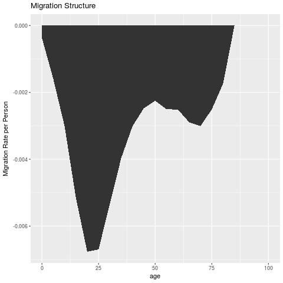

2. Assuming that age-specific net migration rates (in migrants per five-year period) will stay constant to 2020, project the Mexican population forward from 2005 to 2010 and to 2020.

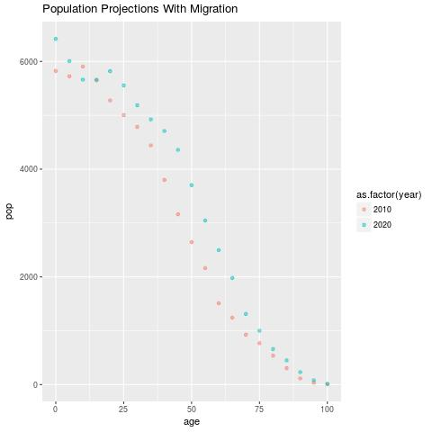

Below are the projections for the population for 2010 and 2020 which account for the net out migration that occurs. Even with the net out migration the population is still growing.

3. Compare your population projections Mexico in 2010 and 2020 with and without migration, numerically, graphically and verbally.

The addition of the migration factor leads to a smaller population in the forecasts. This change is almost negligible in the 2010 projection, however, by the year 2020 we can see that accounting for migration has not only changed the population numbers but also the age structure as well where 25 year olds account for `8.01%` and `8.07%` in the migration vs non-migration models respectively.

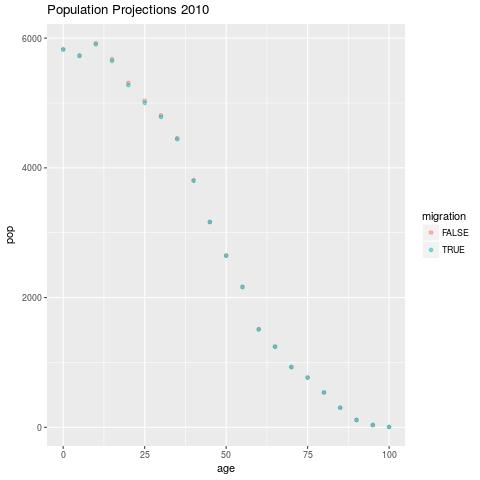

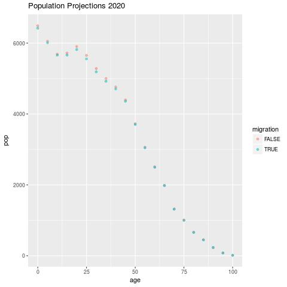

2. Extract the age-specific mortality rates for females in Mexico in 2005 by five-year age groups from the 2015 World Population Prospects
1. Using only the rates for ages 50 above, estimate the parameters of a Gompertz model and a Gompertz-Makeham model for the mortality rates.

The Gompertz model is a two parameter model which estimates mortality by $\hat{m}_{xt} = \alpha exp(\beta x)$. This model has a log-linear form and can be estimated using a least-squres approach. This is done in `R` by using the `lm` function but can also be accomplished by using the `optim` function and specifying the model by hand. The Gompertz-Makeham model adds a constant $\gamma$ to the right hand side and must be fit using the `optim` function.

2. Plot the fitted rates against the observed rates and comment on how good the model fits are. Is there evidence that the additional constant in the Gompertz-Makeham model is needed?

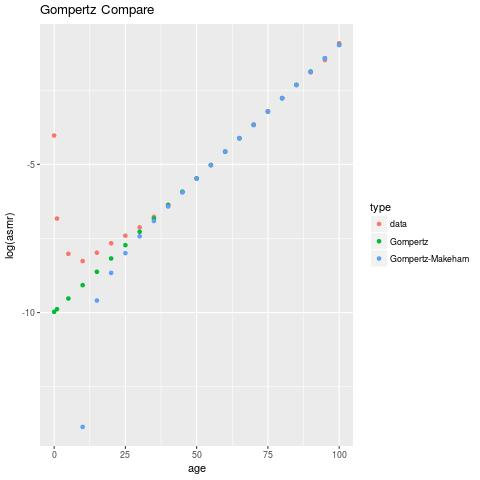

For ages 50 and above both Gompertz model and the Gompertz-Makeham model have comparable results and both visually and statistically as there is very little difference in the least square results of the model.

3. Fit a Heligman-Pollard model to the full set of age-specific mortality rates. Plot the fitted rates against the observed rates and comment on how good the fit is.

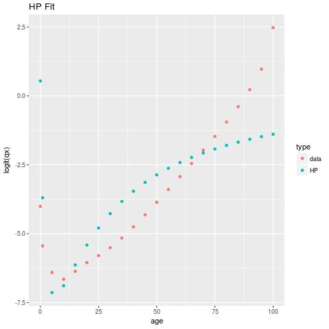

The Heligman-Pollard model is an eight parameter model that has an extremely difficult time fitting on small amounts of data because of the number of parameters and their degree of colinearity. A bayseian framework with strong priors is often suggested to fit the model, however even using `HPbayes` and the exmple data the model was unable to fit well to the data. In this exercise I attempted to fit the modle using a least squares optimization approach and carefully selected start values to model $q_x$ however it seemed due to the lack of prominent middle age mortality hump the model was unable to converge.

4. Select the Coale-Demeny West model life table that best corresponds to these data. Fit a Brass relational model to the data, and fit the observed against the fitted values.

Using RMSE to find the best fit for our mortality rate data suggested using the life table with the highest life expectancy. Using the Brass relational model such that $logit(\hat{q}_x) = \alpha + \beta logit(q^{*}_x))$, where $q^{*}_x$ is the best Coale-Demeny West model life table the expected values yield very reasonable results compared to the observed data.

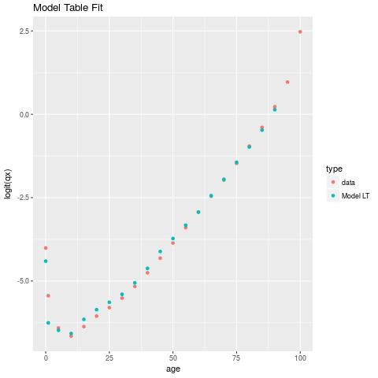

5. Compare the fits of the four models considered to these data. Which one fits the data best?

The Brass relational model life table approach is the model that fits the most realiably and produces the best fit to the full data series by the RMSE. This comparison was marred by the fact that the HP model was unable to reliably fit the data.

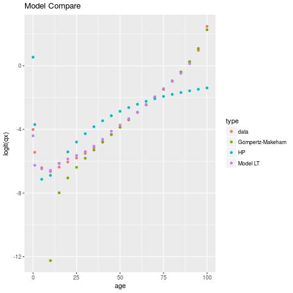

3. Extract the age-specific mortality rates for females in Mexico for each of the 13 five-year periods from 1950 to 2015 by five-year age groups from the 2015 World Population Prospects.
1. Fit the Lee-Carter model to the data using the approximate least squares method described in class, and using the SVD method. Compare the results from these two methods, numerically, graphically and verbally.

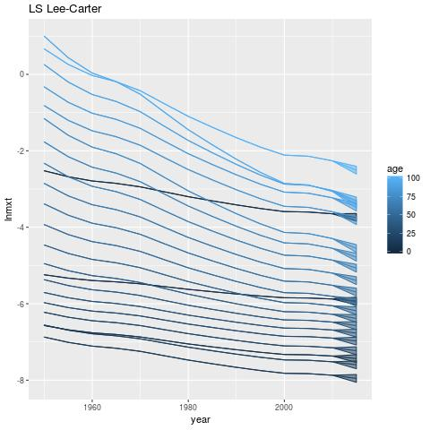

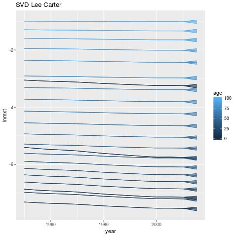

The two different approaches to the lee-carter model fitting process differ most drastically in the degree to which importance is placed on the random walk component. The SVD approach give a value to $\hat{\nu}$ much closer to zero than the least squares approach which is evidenced graphically by the almost non existant slope of the model fits. The two models produce very similar values for the $\hat{\sigma}_{k}$ parameter, however, which dictactes the degree of uncertainty generated by the random walk. Values of `.032` and `.052` are given for the SVD approach and least squares approach respectively.

2. Use the Lee-Carter method to obtain probabilistic forecasts of mortality in Mexico for 2015-2020.

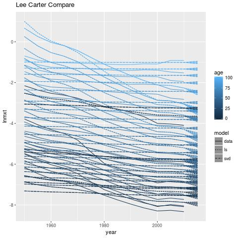

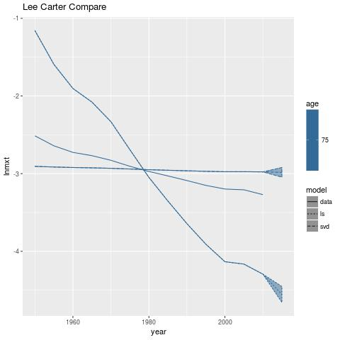

Looking at all age groups we can see what drove each model to choose a flat or a sloped drift in the fitting process. Looking strictly at the age 75 group we can see that the forecasted uncertainty for both model fits is roughly similar.

## Code Appendix

```r
rm(list=ls())
pacman::p_load(pracma, data.table, wpp2015, ggplot2, knitr, bayesPop)

# question 1

asmig <- subset(age.specific.migration(years=2010)$female, name == "Mexico")

leslie_project <- function(les, v, proj=1, migrate=0){
    for(i in 1:proj){
        migpop <- v * migrate
        v <- c(les %*% v) + migpop
    }
    newpop <- v
    return(newpop)
}

data(mxF, pop, percentASFR, tfr)
DF <- subset(as.data.table(mxF), country == "Mexico",
             select=c("age", "2005-2010"))
setnames(DF, c("age", "asmr"))

# we need to combine the first two age groups
DF$age <- as.numeric(as.character(DF$age))
DF[age == 0, asmr:= (DF$asmr[1] + 4 * DF$asmr[2]) / 5]
DF <- subset(DF, age != 1)
DF$pop <- subset(popF, country == "Mexico")$`2005`

ASFR <- subset(percentASFR, country=="Mexico")$`2005` *
    subset(tfr, country == "Mexico")$`2005-2010` / 500

DF[,asfr:=0]
DF[age >=15 & age < 50,asfr:=ASFR]
DF[,asmigr:=asmig[["2005-2010"]] / pop ]

rm(list=c("mxF", "pop", "popF", "popM", "tfr", "percentASFR", "ASFR"))

jpeg('~/Documents/Classes/statdemog/week2/migstructure.jpg')
ggplot(data=DF, aes(x=age, y=asmigr)) + geom_area() +
    labs(y="Migration Rate per Person", title="Migration Structure")
dev.off()

#b
fert <- DF$asfr
age.int <- 5
srb <- 1.05
surv <- c(1, (1 - DF$asmr)**5)
k <- 1/(1 + srb) * surv[1] * 0.5
dbl.fert <- age.int * fert + c(age.int * fert[-1], 0) * surv[-1]
k * dbl.fert

#c
n.age.grps <- length(fert)
n.surv <- length(surv)
lesM <- matrix(0, nrow = n.age.grps, ncol = n.age.grps)
lesM[1, ] <- k * dbl.fert
lesM[2:n.age.grps, 1:(n.age.grps - 1)] <- diag(surv[-c(1,
                                                       n.surv)])
lesM[n.age.grps, n.age.grps] <- surv[n.surv]

for(i in 1:nrow(lesM)){
    for(j in 1:ncol(lesM)){
        if (lesM[i,j] != 0){
            cat(paste0("(", i, ",", j, "): ", sprintf("%05f", lesM[i,j])))
            cat("\n")
        }
    }
}

#d
leslie_project(lesM, DF$pop, 1)

#e
leslie_project(lesM, DF$pop, 3)

DFcompare <- data.table(age=DF$age, pop=leslie_project(lesM, DF$pop, 1),
                        year=2010, migration=F)
DFcompare2 <- copy(DFcompare)
DFcompare2$pop <- leslie_project(lesM, DF$pop, 3)
DFcompare2[,year:=2020]
DFcompare<-rbind(DFcompare, DFcompare2)

jpeg('~/Documents/Classes/statdemog/week2/compareyear.jpg')
ggplot(DFcompare, aes(x=age, y=pop, color=as.factor(year))) + geom_point(alpha=.5) +
    labs(title="Population Projections No Migration")
dev.off()

#f
migrate <- DF$asmigr
migrate

#g
leslie_project(lesM, DF$pop, 1, migrate)
leslie_project(lesM, DF$pop, 3, migrate)

DFcompare <- data.table(age=DF$age, pop=leslie_project(lesM, DF$pop, 1, migrate),
                        year=2010, migration=F)
DFcompare2 <- copy(DFcompare)
DFcompare2$pop <- leslie_project(lesM, DF$pop, 3, migrate)
DFcompare2[,year:=2020]
DFcompare<-rbind(DFcompare, DFcompare2)

jpeg('~/Documents/Classes/statdemog/week2/compareyear2.jpg')
ggplot(DFcompare, aes(x=age, y=pop, color=as.factor(year))) + geom_point(alpha=.5) +
    labs(title="Population Projections With Migration")
dev.off()

#h
DFcompare <- data.table(age=DF$age, pop=leslie_project(lesM, DF$pop, 1),
                        year=2010, migration=F)
DFcompare2 <- copy(DFcompare)
DFcompare2$pop <- leslie_project(lesM, DF$pop, 1, migrate)
DFcompare2[,migration:=T]
DFcompare<-rbind(DFcompare, DFcompare2)

jpeg('~/Documents/Classes/statdemog/week2/comparemig2010.jpg')
ggplot(DFcompare, aes(x=age, y=pop, color=migration)) + geom_point(alpha=.5) +
    labs(title="Population Projections 2010")
dev.off()

DFcompare <- data.table(age=DF$age, pop=leslie_project(lesM, DF$pop, 3),
                        year=2020, migration=F)
DFcompare2 <- copy(DFcompare)
DFcompare2$pop <- leslie_project(lesM, DF$pop, 3, migrate)
DFcompare2[,migration:=T]
DFcompare<-rbind(DFcompare, DFcompare2)

jpeg('~/Documents/Classes/statdemog/week2/comparemig2020.jpg')
ggplot(DFcompare, aes(x=age, y=pop, color=migration)) + geom_point(alpha=.5) +
    labs(title="Population Projections 2020")
dev.off()



# question 2
data(mxF)
DF <- subset(as.data.table(mxF), country == "Mexico",
             select=c("age", "2005-2010"))
setnames(DF, c("age", "asmr"))
DF$age <- as.numeric(as.character(DF$age))

#2a

gmp <- lm(log(asmr) ~ age, data=subset(DF, age >= 50))
summary(gmp)

gmp_predict <- function(p, age){
    alp <- exp(p[1])
    bet <- p[2]
    if (length(p) == 2){
        yhat <-alp * exp(bet * age)
    }
    else{
        gam <- p[3]
        yhat <- alp * exp(bet * age) + gam
    }
    return(yhat)
}

gmpfunc <- function(p, data=subset(DF, age >= 50)){
    yhat <- gmp_predict(p, data$age)
    return(mean((log(data$asmr) - log(yhat))**2)**.5)
}

gmpp <- optim(c(0,0), gmpfunc)
c(gmpp$par[1], gmpp$par[2])
gmp$coefficients
gmp_predict(gmpp$par, subset(DF, age >= 50)$age)
exp(predict(gmp))
subset(DF, age >= 50)$asmr

gmpm <- optim(c(gmpp$par, 0), gmpfunc)
gmpm
gmp_predict(gmpm$par, subset(DF, age >= 50)$age)

# 2b
DF[,qx:=1 - (1-asmr)**5]
DF[age == 0, qx:=1 - (1-asmr)**1]
DF[age == 1, qx:=1 - (1-asmr)**4]
DF$type <- "data"
DF2 <- copy(DF)
DF2$type <- "Gompertz"
DF2[,asmr:= gmp_predict(gmpp$par, age)]
DF2[,qx:=1 - (1-asmr)**5]
DF2[age == 0, qx:=1 - (1-asmr)**1]
DF2[age == 1, qx:=1 - (1-asmr)**4]
DF3 <- copy(DF)
DF3$type <- "Gompertz-Makeham"
DF3[,asmr:= gmp_predict(gmpm$par, age)]
DF3[,qx:=1 - (1-asmr)**5]
DF3[age == 0, qx:=1 - (1-asmr)**1]
DF3[age == 1, qx:=1 - (1-asmr)**4]

DFall <- rbindlist(list(DF, DF2, DF3))

jpeg('~/Documents/Classes/statdemog/week3/comparegomp.jpg')
ggplot(data=DFall, aes(age, log(asmr), color=type)) + geom_point() +
    labs(title="Gompertz Compare")
dev.off()

#2c

hppred <- function(p, age){
    p[1]**((age + p[2])**-p[3]) +
        p[4] * exp(-p[5]*(log(age) - log(p[6]))**2) +
        p[7] * p[8]**age
}


hpfunc <- function(p, data=DF){
    yhat <- hppred(p, data$age)
    return(mean((logit(data$qx) - yhat)**2)**.5)
}

plot(logit(DF$qx))

hpls <- optim(c(0.033, 0.932, 0.204, 0.105, 3.821, 41.458, 0.001, 1.08), hpfunc)
hpls

DF4 <- copy(DF)
DF4$type <- "HP"
DF4[,qx:= inv.logit(hppred(hpls$par, age))]
DFHP <- rbindlist(list(DF, DF4))

ggplot(DFHP, aes(age, qx, color=type)) + geom_point()

jpeg('~/Documents/Classes/statdemog/week3/hpplot.jpg')
ggplot(DFHP, aes(age, logit(qx), color=type)) + geom_point() +
    labs(title="HP Fit")
dev.off()

# 2d
N <- nrow(DF) - 2
rmse <- apply(cdmltw(sex = "F")$nmx, 1, function(x)
    mean((x[1:N] - DF$asmr[1:N])**2)**.5)

mlt <- which(rmse == min(rmse))

mltqx <- logit(cdmltw(sex = "F")$nqx[mlt,1:N])
ltqx <- logit(DF$qx[1:N])

mltlm <- lm(ltqx ~ mltqx)
summary(mltlm)

DF5 <- copy(DF)
DF5$type <- "Model LT"
DF5[1:N, qx:= inv.logit(predict(mltlm))]
DF5[(N+1):nrow(DF5), qx:=NA]
DFHP <- rbindlist(list(DF, DF4, DF5))

ggplot(DFHP, aes(age, qx, color=type)) + geom_point()

jpeg('~/Documents/Classes/statdemog/week3/mltplot.jpg')
ggplot(subset(DFHP, type != "HP"), aes(age, logit(qx), color=type)) +
    geom_point() + labs(title="Model Table Fit")
dev.off()

DFtotal <- rbindlist(list(DF, DF3, DF4, DF5))
ggplot(DFtotal, aes(age, qx, color=type)) + geom_point()

jpeg('~/Documents/Classes/statdemog/week3/allmodelcompare.jpg')
ggplot(DFtotal, aes(age, logit(qx), color=type)) + geom_point() +
    labs(title="Model Compare")
dev.off()

# Question 3

mxt <- log(as.matrix(subset(mxF, country == "Mexico")[,4:16]))
ax <- apply(mxt, 1, mean)
kt <- apply(mxt - ax, 2, mean)
meanadjxt <- mxt - ax

bx <- apply(meanadjxt, 1, function(x) lm(kt ~ 0 + x)$coefficients[[1]])
nu <- (kt[length(kt)] - kt[1]) / (length(kt) - 1)
sigma_k <- sd(kt[2:length(kt)] - kt[1:(length(kt) -1)])
eps <- sd(mxt - (bx %*% t(kt) + ax))

svds <- svd(meanadjxt)
bxsvd <- svds$u[,1]
ktsvd <- svds$v[,1]
nusvd <- (ktsvd[length(ktsvd)] - ktsvd[1]) / (length(ktsvd) - 1)
sigma_ksvd <- sd(ktsvd[2:length(ktsvd)] - ktsvd[1:(length(ktsvd) -1)])
sigma_ksvd

epssvd <- sd(mxt - (bxsvd %*% t(ktsvd) + ax))

kt_forecast <- c(kt, kt[length(kt)] + nu)
ktsvd_forecast <- c(ktsvd, ktsvd[length(ktsvd)] + nusvd)
DFforecast <- data.table(lnmxt=c(bx %*% t(kt_forecast) + ax),
                         age=rep(DF$age, length(kt_forecast)),
                         year=rep(seq(1950, 2015, 5), each=nrow(DF)),
                         model="ls")

DFforecast[,ymin:=lnmxt - 1.96*sigma_k]
DFforecast[year != 2015, ymin:=lnmxt]
DFforecast[,ymax:=lnmxt + 1.96*sigma_k]
DFforecast[year != 2015, ymax:=lnmxt]

jpeg('~/Documents/Classes/statdemog/week3/lsleecarter.jpg')
ggplot(DFforecast, aes(x=year, y=lnmxt, color=age, group=age)) + geom_line() +
    geom_ribbon(aes(ymin=ymin, ymax=ymax, fill=age), alpha=.5) +
    labs(title="LS Lee-Carter")
dev.off()


DFforecastsvd <- data.table(lnmxt=c(bxsvd %*% t(ktsvd_forecast) + ax),
                            age=rep(DF$age, length(ktsvd_forecast)),
                            year=rep(seq(1950, 2015, 5), each=nrow(DF)),
                            model="svd")

DFforecastsvd[,ymin:=lnmxt - 1.96*sigma_ksvd]
DFforecastsvd[year != 2015, ymin:=lnmxt]
DFforecastsvd[,ymax:=lnmxt + 1.96*sigma_ksvd]
DFforecastsvd[year != 2015, ymax:=lnmxt]

jpeg('~/Documents/Classes/statdemog/week3/svdleecarter.jpg')
ggplot(DFforecastsvd, aes(x=year, y=lnmxt, color=age, group=age)) + geom_line() +
    geom_ribbon(aes(ymin=ymin, ymax=ymax, fill=age), alpha=.5) +
    labs(title="SVD Lee Carter")
dev.off()

DFobs <- data.table(lnmxt=c(mxt), age=rep(DF$age, length(ktsvd)),
                    year=rep(seq(1950, 2010, 5), each=nrow(DF)), model="data",
                    ymin=NA, ymax=NA)
ggplot(DFobs, aes(x=year, y=lnmxt, color=age, group=age)) + geom_line()

DFfff <- rbindlist(list(DFobs, DFforecast, DFforecastsvd))

jpeg('~/Documents/Classes/statdemog/week3/allleecarter.jpg')
ggplot(DFfff, aes(x=year, y=lnmxt, color=age,
                  group=interaction(age, model), linetype=model)) +
    geom_line() + geom_ribbon(aes(ymin=ymin, ymax=ymax, fill=age), alpha=.5) +
    labs(title="Lee Carter Compare")
dev.off()

jpeg('~/Documents/Classes/statdemog/week3/allleecarter75.jpg')
ggplot(subset(DFfff, age == 75), aes(x=year, y=lnmxt, color=age,
                  group=interaction(age, model), linetype=model)) +
    geom_line() + geom_ribbon(aes(ymin=ymin, ymax=ymax, fill=age), alpha=.5) +
    labs(title="Lee Carter Compare")
dev.off()
```